# Prueba_22Julio

## Prueba Simulacion

Juan Carlos Benavides C. 22/07/2020

Se buscar encontrar la eficiencia de la generación de números pseudo-aletorios a través de los métodos de cuadrados medios y congruencia lineal, para ello se debe seguir el siguiente proceso:

1. A traves de la misma api generar una semilla diferente.
2. Encontrar el numero de iteraciones hasta que se repita uno de sus datos.
3. Generar 100 simulaciones con diferentes semillas.
4. Generar un histograma con el resultado obtenidos por cada método.
5. Agregar sus conclusiones, opiniones y recomendaciones

Se debe generar un cuaderno de python para la simulación y subir dentro de este apartado.Se buscar encontrar la eficiencia de la generación de números pseudo-aletorios a través de los métodos de cuadrados medios y congruencia lineal, para ello se debe seguir el siguiente proceso:

```
Escriba la semilla :
8998
Escriba la cantidad de digitos :
4
    Valores
0        89
1        45
2        22
3        83
4       100
..      ...
95        5
96        3
97        2
98        6
99        5

[100 rows x 1 columns]
cantidad de repetidos 8
```

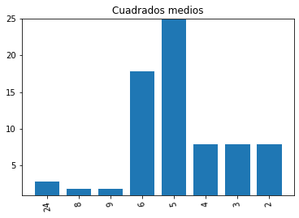

```python
from tabulate import tabulate
from pandas import DataFrame
import matplotlib.pyplot as pp

print("Escriba la semilla :")
Semilla=int(input())
print("Escriba la cantidad de digitos :")
Digitos=int(input())


nu="1"
iteraciones=[]

##Genera ceros
for i in range(0,Digitos):
    nu=nu+"0"
for j in range(0,100):
    i=1
    nui=[]
    val= True
    while val:
        semilla3=Semilla
        Semilla2=semilla3*semilla3
        palabra=str(Semilla2)
        longitud=len(palabra)
        para1=(int((longitud/2))-int((Digitos/2)))
        para2=(int((longitud/2))+int((Digitos/2)))
        Res=palabra[int(para1):int(para2)]
        aleatorio=float(Res)/float(nu)
        Semilla=int(Res)
        if (i==1):
            nui.append(Res)
            i=i+1
        else:
            for x in range(0,len(nui)):
                if (nui[x]==Res):
                    iteraciones.append(i)
                    Semilla=int(nui[0])+200
                    val=False
            nui.append(Res)
            i=i+1


dict_listas = {'Valores' : iteraciones,}
dataframe=DataFrame(dict_listas)
print(dataframe)

aux=[]
repetido = []
unico = []
valores = iteraciones
cont=[]

def contarRep(lista,valor):
    aux=0
    for i in valor:
        for j in lista:
            if i == j:
                aux=aux+1
        cont.append(aux)
        aux=0
    return cont

for x in iteraciones:
    del aux[:]
    if x not in unico:
        unico.append(x)
    else:
        if x not in repetido:
            repetido.append(x)


fra=contarRep(iteraciones,repetido)
print("cantidad de repetidos",len(repetido))
pp.bar(range(len(repetido)), cont, edgecolor='white')
pp.xticks(range(len(repetido)), repetido, rotation=100)
pp.title("Cuadrados medios")
pp.ylim(min(cont)-1, max(cont))
pp.show()
```

```python
print(iteraciones)
```

```
[89, 45, 22, 83, 100, 44, 6, 27, 11, 8, 33, 7, 102, 47, 9, 28, 24, 12, 24, 42, 90, 93, 92, 63, 21, 8, 9, 50, 24, 36, 52, 82, 38, 30, 6, 5, 5, 4, 6, 5, 3, 2, 6, 5, 5, 4, 6, 5, 3, 2, 6, 5, 5, 4, 6, 5, 3, 2, 6, 5, 5, 4, 6, 5, 3, 2, 6, 5, 5, 4, 6, 5, 3, 2, 6, 5, 5, 4, 6, 5, 3, 2, 6, 5, 5, 4, 6, 5, 3, 2,…
```

```
Escriba la semilla :
90000
    Valores
0         4
1         3
2         5
3         4
4         7
..      ...
95        7
96       10
97       21
98      101
99       25

[100 rows x 1 columns]
cantidad de repetidos 21
```

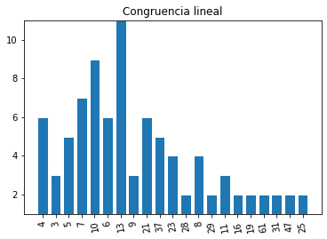

```python
print("Escriba la semilla :")
Semilla=int(input())

a=1
b=2
m=3
iteraciones=[]
for j in range(0,100):
    i=1
    ui1=[]
    xn=0
    ui=0.0
    aux=0
    val= True
    xn=Semilla
    while val:
        aux=((a*xn)+b)%(m)
        ui=aux/m
        xn=aux
        if (i==1):
            ui1.append(ui)
            i=i+1
        else:
            for x in range(0,len(ui1)):
                if (ui1[x]==ui):
                    iteraciones.append(i)
                    Semilla=int(xn)
                    a=a+1
                    b=b+3
                    m=m+1
                    val=False
            ui1.append(ui)
            i=i+1


dict_listas = {'Valores' : iteraciones,}
dataframe=DataFrame(dict_listas)
print(dataframe)

aux=[]
repetido = []
unico = []
cont=[]

def contarRep(lista,valor):
    aux=0
    for i in valor:
        for j in lista:
            if i == j:
                aux=aux+1
        cont.append(aux)
        aux=0
    return cont

for x in iteraciones:
    del aux[:]
    if x not in unico:
        unico.append(x)
    else:
        if x not in repetido:
            repetido.append(x)


fra=contarRep(iteraciones,repetido)
print("cantidad de repetidos",len(repetido))
pp.bar(range(len(repetido)), cont, edgecolor='white')
pp.xticks(range(len(repetido)), repetido, rotation=100)
pp.title("Congruencia lineal")
pp.ylim(min(cont)-1, max(cont))
pp.show()
```

```python
print(iteraciones)
```

```
[4, 3, 5, 4, 7, 3, 10, 5, 6, 4, 13, 7, 4, 5, 9, 10, 10, 3, 7, 6, 23, 5, 21, 13, 28, 7, 29, 13, 11, 5, 16, 9, 13, 10, 37, 10, 13, 6, 21, 4, 8, 6, 37, 23, 47, 6, 43, 21, 25, 13, 53, 28, 21, 8, 10, 29, 30, 13, 61, 11, 19, 6, 13, 16, 34, 10, 67, 13, 71, 11, 19, 37, 61, 10, 31, 13, 79, 4, 82, 21, 42, 7, …
```

### Conclusiones

Los números pseudoaleatorios son una parte importante en la elaboración de modelos de simulación. Los números generados pueden repetirse cíclicamente después de una secuencia corta.

### Recomendacion

La utilización de números primos puede generar ciclos más largos en la generación de números pseudoaleatorios